# Sports Analysis

Noah Hulse

2023-01-15

```r
library(tidyverse)
```

Introduction: In March Madness high seeded teams often struggle and lose their first matchup. For example, a 16 seed has only beat a 1 seed once. I was thinking about what things high seeded teams could do to potentially increase their chance to upset their opponent. This led to me looking at Adjusted Tempo, (An estimate of the tempo (possessions per 40 minutes) a team would have against the team that wants to play at an average Division I tempo). I thought that if a high seeded team were to play slower, they would increase the variability of their matchup by reducing the number of possessions and sample size, thus increasing their chance to win. My analysis of this hypothesis and question is followed.

The data set that I used is Andrew Sundberg’s College Basketball Dataset from Kaggle. This data set contains information about college basketball teams from 2013 to 2021. There is data about the regular season, as well as the teams’ seed and result in the March Madness tournament.

First I read in the data set and created the table “upset” that only contains teams that are seeded 9 or higher that made it to the round of 32 (guaranteeing they played a lower seeded team and upset them). Then I created the table “upset.no” that also only contained teams seeded 9 or higher. I decided to filter out teams that were seeded 15 or 16 to remove some of the really bad teams that might skew the data. Then I filtered it again to only include teams that did not have an upset (Lost in round of 68 or 64).

We can see that across 9 seasons an upset happened in the round of 64 63 times.

```r
data = read_csv("cbb2.csv")
data
```

```
## # A tibble: 2,455 × 24
##    TEAM      CONF      G     W ADJOE ADJDE BARTHAG EFG_O EFG_D   TOR  TORD   ORB
##    <chr>     <chr> <dbl> <dbl> <dbl> <dbl>   <dbl> <dbl> <dbl> <dbl> <dbl> <dbl>
##  1 North Ca… ACC      40    33  123.  94.9   0.953  52.6  48.1  15.4  18.2  40.7
##  2 Wisconsin B10      40    36  129.  93.6   0.976  54.8  47.7  12.4  15.8  32.1
##  3 Michigan  B10      40    33  114.  90.4   0.938  53.9  47.7  14    19.5  25.5
##  4 Texas Te… B12      38    31  115.  85.2   0.970  53.5  43    17.7  22.8  27.4
##  5 Gonzaga   WCC      39    37  118.  86.3   0.973  56.6  41.1  16.2  17.1  30
##  6 Kentucky  SEC      40    29  117.  96.2   0.906  49.9  46    18.1  16.1  42
##  7 Michigan  B10      38    30  122.  93.7   0.952  54.6  48    14.6  18.7  32.5
##  8 Duke      ACC      39    35  125.  90.6   0.976  56.6  46.5  16.3  18.6  35.8
##  9 Virginia  ACC      38    35  123   89.9   0.974  55.2  44.7  14.7  17.5  30.4
## 10 North Ca… ACC      39    33  121   91.5   0.962  51.7  48.1  16.2  18.6  41.3
## # … with 2,445 more rows, and 12 more variables: DRB <dbl>, FTR <dbl>,
## #   FTRD <dbl>, TWOP_O <dbl>, TWOP_D <dbl>, THREEP_O <dbl>, THREEP_D <dbl>,
## #   ADJ_T <dbl>, WAB <dbl>, POSTSEASON <chr>, SEED <dbl>, YEAR <dbl>
## # ℹ Use `print(n = ...)` to see more rows, and `colnames()` to see all variable names
```

```r
upset = data %>% filter(SEED > 8)  %>% filter(!grepl('R64', POSTSEASON)) %>% filter(!grepl('R68', POSTSEASON))
upset
```

```
## # A tibble: 63 × 24
##    TEAM      CONF      G     W ADJOE ADJDE BARTHAG EFG_O EFG_D   TOR  TORD   ORB
##    <chr>     <chr> <dbl> <dbl> <dbl> <dbl>   <dbl> <dbl> <dbl> <dbl> <dbl> <dbl>
##  1 Florida … ACC      35    23  113.  96.4   0.863  53.2  48.4  17.8  19.4  32.3
##  2 Kansas S… B12      37    25  110.  93.7   0.858  52.6  49.1  17.2  21.6  25.9
##  3 Xavier    BE       38    24  116.  97.9   0.871  51.9  51.6  18.4  17.5  34.5
##  4 Dayton    A10      37    26  113   99.1   0.819  52.4  48.8  18.1  18.8  33.9
##  5 Syracuse  ACC      37    23  112.  93.6   0.886  50    47.3  18.1  20.4  33.5
##  6 Loyola C… MVC      37    32  110.  95.4   0.844  57.7  47.4  19.1  19.4  22.1
##  7 Wichita … MVC      39    30  111.  91     0.904  50    45.3  19.4  20    38
##  8 Dayton    A10      36    27  107   94.5   0.806  52.9  47.3  17.9  21.1  23.3
##  9 VCU       A10      36    25  112.  94.2   0.881  51    49.2  16.3  21.4  33.2
## 10 Rhode Is… A10      35    25  111.  94.1   0.872  50.8  45    16.4  19.4  32.8
## # … with 53 more rows, and 12 more variables: DRB <dbl>, FTR <dbl>, FTRD <dbl>,
## #   TWOP_O <dbl>, TWOP_D <dbl>, THREEP_O <dbl>, THREEP_D <dbl>, ADJ_T <dbl>,
## #   WAB <dbl>, POSTSEASON <chr>, SEED <dbl>, YEAR <dbl>
## # ℹ Use `print(n = ...)` to see more rows, and `colnames()` to see all variable names
```

```r
upset.no = data %>% filter(SEED > 8) %>% filter(SEED < 15) %>% filter(grepl("R64|R68", POSTSEASON))
upset.no
```

```
## # A tibble: 122 × 24
##    TEAM      CONF      G     W ADJOE ADJDE BARTHAG EFG_O EFG_D   TOR  TORD   ORB
##    <chr>     <chr> <dbl> <dbl> <dbl> <dbl>   <dbl> <dbl> <dbl> <dbl> <dbl> <dbl>
##  1 Davidson  A10      31    23  118. 102.    0.844  55.4  49.3  14.1  17    29.6
##  2 VCU       A10      35    26  108.  95.9   0.799  51    47.5  17.8  21    31.3
##  3 Davidson  A10      33    21  117  102.    0.823  57.4  51.2  14.5  16.2  22.6
##  4 St. Bona… A10      34    26  110.  99.7   0.748  51.6  49    16.3  20.4  29.3
##  5 Saint Lo… A10      36    23  101.  95.7   0.660  46.7  46.9  19.3  19.4  36
##  6 Pittsbur… ACC      32    20  114.  96.9   0.866  51.1  50    17.5  16.9  36.9
##  7 Virginia… ACC      33    22  118. 102.    0.840  56.9  51    17.2  16.5  23.4
##  8 North Ca… ACC      33    21  116. 101.    0.821  53.4  51.6  16.8  20.4  33.4
##  9 Albany    AE       33    24  105. 102.    0.575  49.9  49.6  18.8  20.1  32.6
## 10 Stony Br… AE       31    24  105.  99.2   0.648  52.2  47.6  17.3  18.4  34.8
## # … with 112 more rows, and 12 more variables: DRB <dbl>, FTR <dbl>,
## #   FTRD <dbl>, TWOP_O <dbl>, TWOP_D <dbl>, THREEP_O <dbl>, THREEP_D <dbl>,
## #   ADJ_T <dbl>, WAB <dbl>, POSTSEASON <chr>, SEED <dbl>, YEAR <dbl>
## # ℹ Use `print(n = ...)` to see more rows, and `colnames()` to see all variable names
```

```r
mean(upset$ADJ_T)
```

```
## [1] 67.27937
```

```r
mean(upset.no$ADJ_T)
```

```
## [1] 68.06557
```

```r
t.test(upset$ADJ_T, upset.no$ADJ_T)
```

```
##
##  Welch Two Sample t-test
##
## data:  upset$ADJ_T and upset.no$ADJ_T
## t = -1.7296, df = 145.67, p-value = 0.08581
## alternative hypothesis: true difference in means is not equal to 0
## 95 percent confidence interval:
##  -1.6845785  0.1121612
## sample estimates:
## mean of x mean of y
##  67.27937  68.06557
```

I was curious as to if high seeded teams that made it even farther than the round of 32 played slower than the teams eliminated in the round of 32.

```r
upset.far = data %>% filter(SEED > 8) %>% filter (!grepl('R64|R68|R32', POSTSEASON))
upset.far
```

```
## # A tibble: 16 × 24
##    TEAM      CONF      G     W ADJOE ADJDE BARTHAG EFG_O EFG_D   TOR  TORD   ORB
##    <chr>     <chr> <dbl> <dbl> <dbl> <dbl>   <dbl> <dbl> <dbl> <dbl> <dbl> <dbl>
##  1 Florida … ACC      35    23  113.  96.4   0.863  53.2  48.4  17.8  19.4  32.3
##  2 Kansas S… B12      37    25  110.  93.7   0.858  52.6  49.1  17.2  21.6  25.9
##  3 Xavier    BE       38    24  116.  97.9   0.871  51.9  51.6  18.4  17.5  34.5
##  4 Dayton    A10      37    26  113   99.1   0.819  52.4  48.8  18.1  18.8  33.9
##  5 Syracuse  ACC      37    23  112.  93.6   0.886  50    47.3  18.1  20.4  33.5
##  6 Loyola C… MVC      37    32  110.  95.4   0.844  57.7  47.4  19.1  19.4  22.1
##  7 Wichita … MVC      39    30  111.  91     0.904  50    45.3  19.4  20    38
##  8 Syracuse  ACC      37    23  106   92.1   0.834  46.9  46.2  19.1  19.5  34.7
##  9 UCLA      P12      36    22  112.  96.6   0.842  49.6  48.5  17.6  17.9  33.8
## 10 Oregon    P12      38    25  108.  91.7   0.869  52    46.4  17.8  20.9  29.6
## 11 Gonzaga   WCC      35    27  117.  94.5   0.924  55.2  44.8  17.1  15.1  32.1
## 12 Stanford  P12      36    23  112.  96.5   0.844  51.3  48    17    17    29.3
## 13 Tennessee SEC      36    23  118.  93.4   0.937  49.8  46.5  16.8  16.9  39.7
## 14 Oregon    P12      37    28  105.  88.6   0.873  49.3  46.4  21.4  22    35.8
## 15 La Salle  A10      34    24  112   96.2   0.852  51.9  49.3  17.1  21.3  29
## 16 Florida … ASun     35    24  103.  96.3   0.695  51.6  46.9  21    22.1  32.5
## # … with 12 more variables: DRB <dbl>, FTR <dbl>, FTRD <dbl>, TWOP_O <dbl>,
## #   TWOP_D <dbl>, THREEP_O <dbl>, THREEP_D <dbl>, ADJ_T <dbl>, WAB <dbl>,
## #   POSTSEASON <chr>, SEED <dbl>, YEAR <dbl>
## # ℹ Use `colnames()` to see all variable names
```

We can see that the mean is slightly lower for just the teams that made it further than the round of 32 compared to all teams that got an upset. (66.79 vs 67.28)

```r
mean(upset.far$ADJ_T)
```

```
## [1] 66.79375
```

I wanted to make a variable that would tell me if a team had an upset or not, so I added a new column to the data “Upset” where a team received a 1 if they had an upset and a 0 if they did not.

```r
data.highseeds = data %>% filter(SEED > 8)

data.upset <- data.highseeds %>%
  mutate(Upset = ifelse(POSTSEASON == "R64" | POSTSEASON == "R68", 0, 1))

data.upset
```

```
## # A tibble: 252 × 25
##    TEAM      CONF      G     W ADJOE ADJDE BARTHAG EFG_O EFG_D   TOR  TORD   ORB
##    <chr>     <chr> <dbl> <dbl> <dbl> <dbl>   <dbl> <dbl> <dbl> <dbl> <dbl> <dbl>
##  1 Florida … ACC      35    23  113.  96.4   0.863  53.2  48.4  17.8  19.4  32.3
##  2 Kansas S… B12      37    25  110.  93.7   0.858  52.6  49.1  17.2  21.6  25.9
##  3 Xavier    BE       38    24  116.  97.9   0.871  51.9  51.6  18.4  17.5  34.5
##  4 Dayton    A10      37    26  113   99.1   0.819  52.4  48.8  18.1  18.8  33.9
##  5 Syracuse  ACC      37    23  112.  93.6   0.886  50    47.3  18.1  20.4  33.5
##  6 Loyola C… MVC      37    32  110.  95.4   0.844  57.7  47.4  19.1  19.4  22.1
##  7 Wichita … MVC      39    30  111.  91     0.904  50    45.3  19.4  20    38
##  8 Dayton    A10      36    27  107   94.5   0.806  52.9  47.3  17.9  21.1  23.3
##  9 VCU       A10      36    25  112.  94.2   0.881  51    49.2  16.3  21.4  33.2
## 10 Rhode Is… A10      35    25  111.  94.1   0.872  50.8  45    16.4  19.4  32.8
## # … with 242 more rows, and 13 more variables: DRB <dbl>, FTR <dbl>,
## #   FTRD <dbl>, TWOP_O <dbl>, TWOP_D <dbl>, THREEP_O <dbl>, THREEP_D <dbl>,
## #   ADJ_T <dbl>, WAB <dbl>, POSTSEASON <chr>, SEED <dbl>, YEAR <dbl>,
## #   Upset <dbl>
## # ℹ Use `print(n = ...)` to see more rows, and `colnames()` to see all variable names
```

Looking at the boxplot we can see that for the teams that did have an upset, the upper quartile, lower quartile, and mean for adjusted tempo were all lower than the teams that did not have an upset.

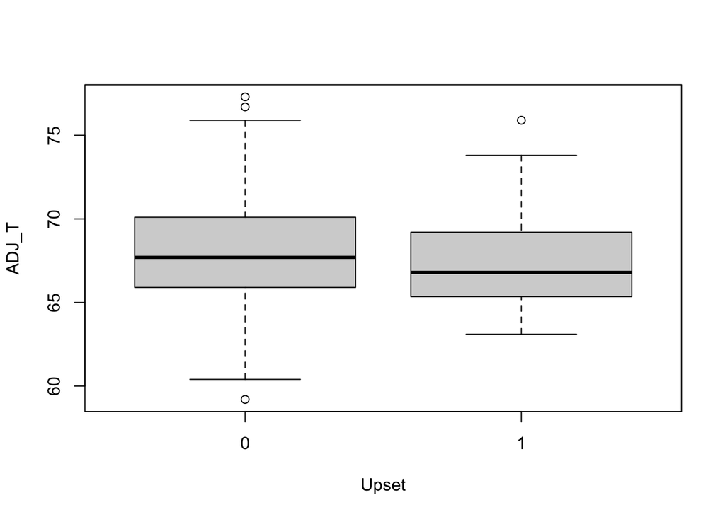

```r
boxplot(ADJ_T~Upset, data.upset)
```

In conclusion, there is evidence that a lower Adjusted Tempo could help high seeds in the March Madness tournament. If a coach knows that they are underdogs and need an upset, it could be beneficial to play slower.